# NBA Statistical Analysis

Andhy Gomez, Kelly Rivera

# R Programming

## Packages and Libraries

### Install libraries

```r
#install.packages("tidyverse")
#install.packages("knitr")
#install.packages("rmarkdown")
#install.packages("forecast")
#install.packages("party")
#install.packages("TSA")
#install.packages("party")
#install.packages("caTools")
#install.packages("Metrics")
```

### Load libraries

```r
library(tidyverse)
library(knitr)
library(forecast)
library(reshape2)
library(caTools)
library(party)
library(rmarkdown)
library(Metrics)
```

## General Prep

Firstly we will be looking at data throughout the regular season since the three point line was implemented.

### Create data frames

```r
# General Data
seasonStats <- read.csv("Data/Seasons_Stats.csv")
```

### View the data

```r
head(seasonStats)
```

```
##   X Year          Player Pos Age  Tm  G GS MP PER   TS. X3PAr   FTr ORB. DRB.
## 1 0 1950 Curly Armstrong G-F  31 FTW 63 NA NA  NA 0.368    NA 0.467   NA   NA
## 2 1 1950    Cliff Barker  SG  29 INO 49 NA NA  NA 0.435    NA 0.387   NA   NA
## 3 2 1950   Leo Barnhorst  SF  25 CHS 67 NA NA  NA 0.394    NA 0.259   NA   NA
## 4 3 1950      Ed Bartels   F  24 TOT 15 NA NA  NA 0.312    NA 0.395   NA   NA
## 5 4 1950      Ed Bartels   F  24 DNN 13 NA NA  NA 0.308    NA 0.378   NA   NA
## 6 5 1950      Ed Bartels   F  24 NYK  2 NA NA  NA 0.376    NA 0.750   NA   NA
##   TRB. AST. STL. BLK. TOV. USG. blanl  OWS  DWS   WS WS.48 blank2 OBPM DBPM BPM
## 1   NA   NA   NA   NA   NA   NA    NA -0.1  3.6  3.5    NA     NA   NA   NA  NA
## 2   NA   NA   NA   NA   NA   NA    NA  1.6  0.6  2.2    NA     NA   NA   NA  NA
## 3   NA   NA   NA   NA   NA   NA    NA  0.9  2.8  3.6    NA     NA   NA   NA  NA
## 4   NA   NA   NA   NA   NA   NA    NA -0.5 -0.1 -0.6    NA     NA   NA   NA  NA
## 5   NA   NA   NA   NA   NA   NA    NA -0.5 -0.1 -0.6    NA     NA   NA   NA  NA
## 6   NA   NA   NA   NA   NA   NA    NA  0.0  0.0  0.0    NA     NA   NA   NA  NA
##   VORP  FG FGA   FG. X3P X3PA X3P. X2P X2PA  X2P.  eFG.  FT FTA   FT. ORB DRB
## 1   NA 144 516 0.279  NA   NA   NA 144  516 0.279 0.279 170 241 0.705  NA  NA
## 2   NA 102 274 0.372  NA   NA   NA 102  274 0.372 0.372  75 106 0.708  NA  NA
## 3   NA 174 499 0.349  NA   NA   NA 174  499 0.349 0.349  90 129 0.698  NA  NA
## 4   NA  22  86 0.256  NA   NA   NA  22   86 0.256 0.256  19  34 0.559  NA  NA
## 5   NA  21  82 0.256  NA   NA   NA  21   82 0.256 0.256  17  31 0.548  NA  NA
## 6   NA   1   4 0.250  NA   NA   NA   1    4 0.250 0.250   2   3 0.667  NA  NA
##   TRB AST STL BLK TOV  PF PTS
## 1  NA 176  NA  NA  NA 217 458
## 2  NA 109  NA  NA  NA  99 279
## 3  NA 140  NA  NA  NA 192 438
## 4  NA  20  NA  NA  NA  29  63
## 5  NA  20  NA  NA  NA  27  59
## 6  NA   0  NA  NA  NA   2   4
```

### Subset the data

```r
# Fetch only the years from when the 3-point line was implemented
post3pl <- subset(seasonStats, Year >= 1980)
head(post3pl)
```

```
##         X Year               Player Pos Age  Tm  G GS   MP  PER   TS. X3PAr
## 5728 5727 1980 Kareem Abdul-Jabbar*   C  32 LAL 82 NA 3143 25.3 0.639 0.001
## 5729 5728 1980        Tom Abernethy  PF  25 GSW 67 NA 1222 11.0 0.511 0.003
## 5730 5729 1980          Alvan Adams   C  25 PHO 75 NA 2168 19.2 0.571 0.002
## 5731 5730 1980      Tiny Archibald*  PG  31 BOS 80 80 2864 15.3 0.574 0.023
## 5732 5731 1980        Dennis Awtrey   C  31 CHI 26 NA  560  7.4 0.524 0.000
## 5733 5732 1980           Gus Bailey  SG  28 WSB 20 NA  180  9.3 0.467 0.029
##        FTr ORB. DRB. TRB. AST. STL. BLK. TOV. USG. blanl OWS DWS   WS WS.48
## 5728 0.344  7.2 22.2 15.4 16.5  1.2  4.6 15.7 24.1    NA 9.5 5.3 14.8 0.227
## 5729 0.258  5.4 12.0  8.6  9.3  1.4  0.6  9.9 13.3    NA 1.2 0.8  2.0 0.080
## 5730 0.270  8.2 22.4 15.4 21.6  2.3  1.4 18.2 21.9    NA 3.1 3.9  7.0 0.155
## 5731 0.548  2.3  5.3  3.8 30.2  1.7  0.2 19.7 17.0    NA 5.9 2.9  8.9 0.148
## 5732 0.833  6.0 16.9 11.5  9.0  1.0  1.5 24.8  7.9    NA 0.1 0.5  0.6 0.053
## 5733 0.371  3.3 12.4  7.8 17.8  1.8  1.2 21.3 11.3    NA 0.0 0.2  0.2 0.043
##      blank2 OBPM DBPM  BPM VORP  FG  FGA   FG. X3P X3PA  X3P. X2P X2PA  X2P.
## 5728     NA  4.0  2.7  6.7  6.8 835 1383 0.604   0    1 0.000 835 1382 0.604
## 5729     NA -1.5 -0.1 -1.6  0.1 153  318 0.481   0    1 0.000 153  317 0.483
## 5730     NA  1.6  2.8  4.4  3.5 465  875 0.531   0    2 0.000 465  873 0.533
## 5731     NA  1.1 -1.1  0.0  1.5 383  794 0.482   4   18 0.222 379  776 0.488
## 5732     NA -2.9  1.5 -1.4  0.1  27   60 0.450   0    0    NA  27   60 0.450
## 5733     NA -3.7  1.3 -2.4  0.0  16   35 0.457   1    1 1.000  15   34 0.441
##       eFG.  FT FTA   FT. ORB DRB TRB AST STL BLK TOV  PF  PTS
## 5728 0.604 364 476 0.765 190 696 886 371  81 280 297 216 2034
## 5729 0.481  56  82 0.683  62 129 191  87  35  12  39 118  362
## 5730 0.531 188 236 0.797 158 451 609 322 108  55 218 237 1118
## 5731 0.485 361 435 0.830  59 138 197 671 106  10 242 218 1131
## 5732 0.450  32  50 0.640  29  86 115  40  12  15  27  66   86
## 5733 0.471   5  13 0.385   6  22  28  26   7   4  11  18   38
```

```r
# Select only columns that will be used for analysis
newPost3pl <- select(post3pl, Year, Player, Tm, X2PA, X3PAr, X3P, X3PA, X3P., PTS)
head(newPost3pl)
```

```
##      Year               Player  Tm X2PA X3PAr X3P X3PA  X3P.  PTS
## 5728 1980 Kareem Abdul-Jabbar* LAL 1382 0.001   0    1 0.000 2034
## 5729 1980        Tom Abernethy GSW  317 0.003   0    1 0.000  362
## 5730 1980          Alvan Adams PHO  873 0.002   0    2 0.000 1118
## 5731 1980      Tiny Archibald* BOS  776 0.023   4   18 0.222 1131
## 5732 1980        Dennis Awtrey CHI   60 0.000   0    0    NA   86
## 5733 1980           Gus Bailey WSB   34 0.029   1    1 1.000   38
```

### Convert Year to Factors

```r
#newPost3pl$Year <- as.factor(newPost3pl$Year)
head(newPost3pl)
```

```
##      Year               Player  Tm X2PA X3PAr X3P X3PA  X3P.  PTS
## 5728 1980 Kareem Abdul-Jabbar* LAL 1382 0.001   0    1 0.000 2034
## 5729 1980        Tom Abernethy GSW  317 0.003   0    1 0.000  362
## 5730 1980          Alvan Adams PHO  873 0.002   0    2 0.000 1118
## 5731 1980      Tiny Archibald* BOS  776 0.023   4   18 0.222 1131
## 5732 1980        Dennis Awtrey CHI   60 0.000   0    0    NA   86
## 5733 1980           Gus Bailey WSB   34 0.029   1    1 1.000   38
```

### Group data by year

```r
by_year <- group_by(newPost3pl, Year)
avg3pa <- summarise(by_year, Average3PA = mean(X3PA), Average2PA = mean(X2PA))
head(avg3pa)
```

```
## # A tibble: 6 x 3
##    Year Average3PA Average2PA
##   <int>      <dbl>      <dbl>
## 1  1980       15.5       494.
## 2  1981       11.5       476.
## 3  1982       12.5       470.
## 4  1983       11.7       460.
## 5  1984       13.4       482.
## 6  1985       16.6       457.
```

### Visualize the data

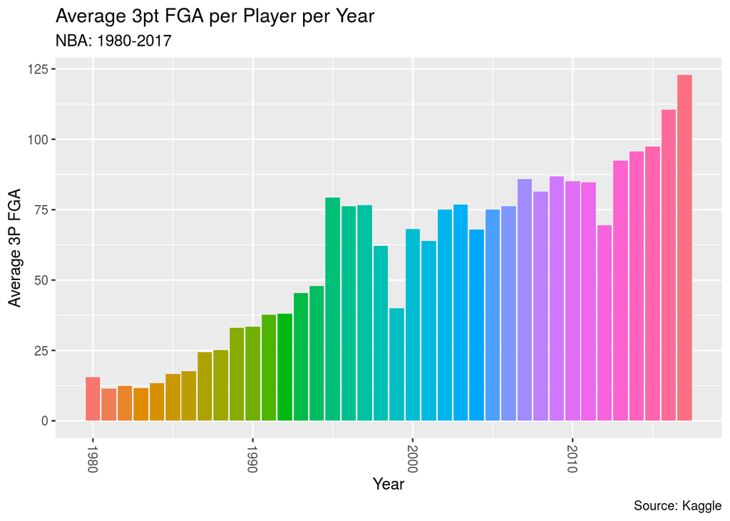

```r
ggplot(data = avg3pa, mapping = aes(x = Year, y = Average3PA, fill = as.factor(Year))) +
        geom_col(show.legend = FALSE) +
        theme(axis.text.x = element_text(angle =- 90, vjust = 0.5)) +
        labs(title = "Average 3pt FGA per Player per Year" ,
         subtitle = "NBA: 1980-2017" ,
         caption = "Source: Kaggle",
         x = "Year", y = "Average 3P FGA")
```

```r
# Average 3pt fga in 1980
avg3pa1980 <- avg3pa$Average3PA[1]
avg3pa2017 <- avg3pa$Average3PA[38]
```

The bar graph clearly shows a meteoric rise in popularity of the 3 point shot. In the year it was first implemented the average player would take 15.4677871 three-point shots in a whole season whereas in the 2017 season the average player takes 122.9176471 in a season. Nearly 8 times as much as in 1980.

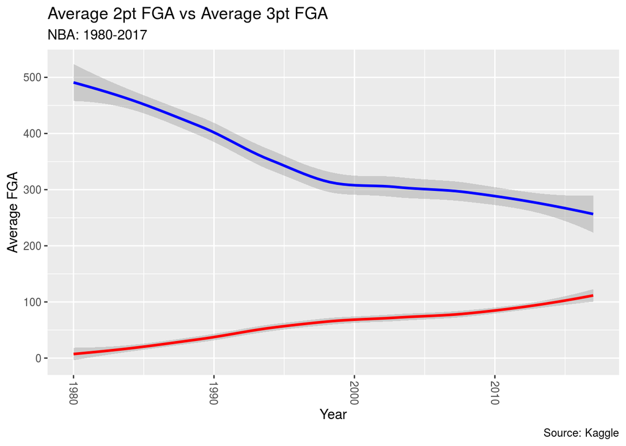

```r
ggplot() +
  geom_smooth(data = avg3pa, aes(x = Year, y = Average2PA), color = "blue",
              method = loess) +
  geom_smooth(data = avg3pa, aes(x = Year, y = Average3PA), color = "red",
              method = loess) +
  theme(axis.text.x = element_text(angle =- 90, vjust = 0.5)) +
  labs(title = "Average 2pt FGA vs Average 3pt FGA" ,
         subtitle = "NBA: 1980-2017" ,
         caption = "Source: Kaggle",
         x = "Year", y = "Average FGA")
```

## Time Series

### Import Data

```r
teams <- read.csv("Data/basketball_teams.csv")
```

### Subset Data to be post 1980 and NBA teams only

```r
nba80sTo05 <- subset(teams, lgID == "NBA" & year >= 1980 & year <= 2005)
head(nba80sTo05)
```

```
##     year lgID tmID franchID confID divID rank confRank playoff
## 527 1980  NBA  ATL      ATL     EC    CD    4        8
## 528 1980  NBA  BOS      BOS     EC    AT    1        1      NC
## 529 1980  NBA  CHI      CHI     EC    CD    2        5      CS
## 530 1980  NBA  CLE      CLE     EC    CD    5        9
## 531 1980  NBA  DAL      DAL     WC    MW    6       12
## 532 1980  NBA  DEN      DEN     WC    MW    4        8
##                    name o_fgm o_fga o_ftm o_fta o_3pm o_3pa o_oreb o_dreb o_reb
## 527       Atlanta Hawks  3291  6866  2012  2590    10    82   1201   2224  3425
## 528      Boston Celtics  3581  7099  1781  2369    65   241   1155   2424  3579
## 529       Chicago Bulls  3457  6903  1985  2563    38   179   1227   2475  3702
## 530 Cleveland Cavaliers  3556  7609  1486  1909    72   249   1258   2243  3501
## 531    Dallas Mavericks  3204  6928  1868  2487    46   165   1109   2177  3286
## 532      Denver Nuggets  3784  7960  2388  3051    30   145   1325   2497  3822
##     o_asts o_pf o_stl o_to o_blk o_pts d_fgm d_fga d_ftm d_fta d_3pm d_3pa
```

[output cut: 34 more lines]

```r
nba06To11 <- subset(teams, lgID == "NBA" & year >= 2006)
head(nba06To11)
```

```
##      year lgID tmID franchID confID divID rank confRank playoff
## 1219 2006  NBA  ATL      ATL     EC    SE    5       13
## 1220 2006  NBA  BOS      BOS     EC    AT    5       15
## 1221 2006  NBA  CHA      CHA     EC    SE    4       11
## 1222 2006  NBA  CHI      CHI     EC    CD    3        5      CS
## 1223 2006  NBA  CLE      CLE     EC    CD    2        2       F
## 1224 2006  NBA  DAL      DAL     WC    SW    1        1      C1
##                     name o_fgm o_fga o_ftm o_fta o_3pm o_3pa o_oreb o_dreb
## 1219       Atlanta Hawks  2831  6372  1677  2203   341  1038    976   2312
## 1220      Boston Celtics  2858  6454  1670  2178   471  1283    918   2391
## 1221   Charlotte Bobcats  2960  6643  1568  2136   457  1280    920   2346
## 1222       Chicago Bulls  3046  6663  1528  2083   480  1237    984   2597
## 1223 Cleveland Cavaliers  2978  6658  1484  2134   494  1404   1039   2529
## 1224    Dallas Mavericks  3010  6442  1646  2045   535  1404    920   2515
##      o_reb o_asts o_pf o_stl o_to o_blk o_pts d_fgm d_fga d_ftm d_fta d_3pm
```

[output cut: 34 more lines]

```r
nbaNow <- subset(teams, lgID == "NBA" & year >= 1980)
head(nbaNow)
```

```
##     year lgID tmID franchID confID divID rank confRank playoff
## 527 1980  NBA  ATL      ATL     EC    CD    4        8
## 528 1980  NBA  BOS      BOS     EC    AT    1        1      NC
## 529 1980  NBA  CHI      CHI     EC    CD    2        5      CS
## 530 1980  NBA  CLE      CLE     EC    CD    5        9
## 531 1980  NBA  DAL      DAL     WC    MW    6       12
## 532 1980  NBA  DEN      DEN     WC    MW    4        8
##                    name o_fgm o_fga o_ftm o_fta o_3pm o_3pa o_oreb o_dreb o_reb
## 527       Atlanta Hawks  3291  6866  2012  2590    10    82   1201   2224  3425
## 528      Boston Celtics  3581  7099  1781  2369    65   241   1155   2424  3579
## 529       Chicago Bulls  3457  6903  1985  2563    38   179   1227   2475  3702
## 530 Cleveland Cavaliers  3556  7609  1486  1909    72   249   1258   2243  3501
## 531    Dallas Mavericks  3204  6928  1868  2487    46   165   1109   2177  3286
## 532      Denver Nuggets  3784  7960  2388  3051    30   145   1325   2497  3822
##     o_asts o_pf o_stl o_to o_blk o_pts d_fgm d_fga d_ftm d_fta d_3pm d_3pa
```

[output cut: 34 more lines]

##Time Series analysis of 3PA

### Create Training and Testing Sets

```r
# training set:
avg3pa$Year <- as.integer(avg3pa$Year)
train3pa <- subset(avg3pa, Year >= 1980 & Year <= 2005)
train3paSeries = ts(train3pa[, 2], frequency = 1)
# test set:
test3pa <- subset(avg3pa, Year > 2004)
test3paSeries = ts(test3pa[, 2], frequency = 1)
```

### Model

```r
teamModel <- auto.arima(train3paSeries)
teamForecast <-forecast(teamModel)
head(teamForecast)
```

```
## $method
## [1] "ARIMA(0,1,0)"
##
## $model
## Series: train3paSeries
## ARIMA(0,1,0)
##
## sigma^2 estimated as 119.7:  log likelihood=-95.29
## AIC=192.58   AICc=192.75   BIC=193.8
##
## $level
## [1] 80 95
##
## $mean
## Time Series:
## Start = 27
## End = 36
## Frequency = 1
##  [1] 75.05299 75.05299 75.05299 75.05299 75.05299 75.05299 75.05299 75.05299
##  [9] 75.05299 75.05299
##
## $lower
## Time Series:
## Start = 27
## End = 36
## Frequency = 1
##         80%       95%
## 27 61.02976 53.606311
## 28 55.22115 44.722805
## 29 50.76404 37.906251
## 30 47.00653 32.159631
## 31 43.69609 27.096756
## 32 40.70323 22.519568
## 33 37.95101 18.310409
## 34 35.38931 14.392619
## 35 32.98330 10.712950
## 36 30.70764  7.232633
##
## $upper
## Time Series:
## Start = 27
## End = 36
## Frequency = 1
##          80%       95%
## 27  89.07622  96.49967
## 28  94.88483 105.38318
## 29  99.34194 112.19973
## 30 103.09945 117.94635
## 31 106.40989 123.00923
## 32 109.40275 127.58642
## 33 112.15497 131.79557
## 34 114.71668 135.71336
## 35 117.12268 139.39303
## 36 119.39834 142.87335
```

### History and Predictions

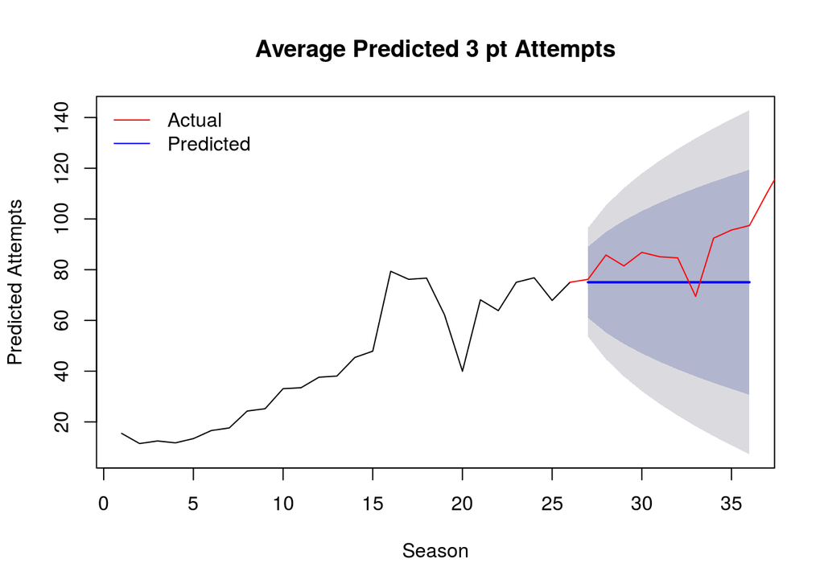

```r
plot(teamForecast, main = "Average Predicted 3 pt Attempts", ylab = "Predicted Attempts", xlab = "Season")
lines(x = 26:38, y = test3paSeries, col="red")
legend("topleft", lty = 1, bty = "n", col = c("red","blue"), c("Actual","Predicted"))
```

## Linear Regression

### Correlation: Pairs Plot

Pair plot to see correlation between variables

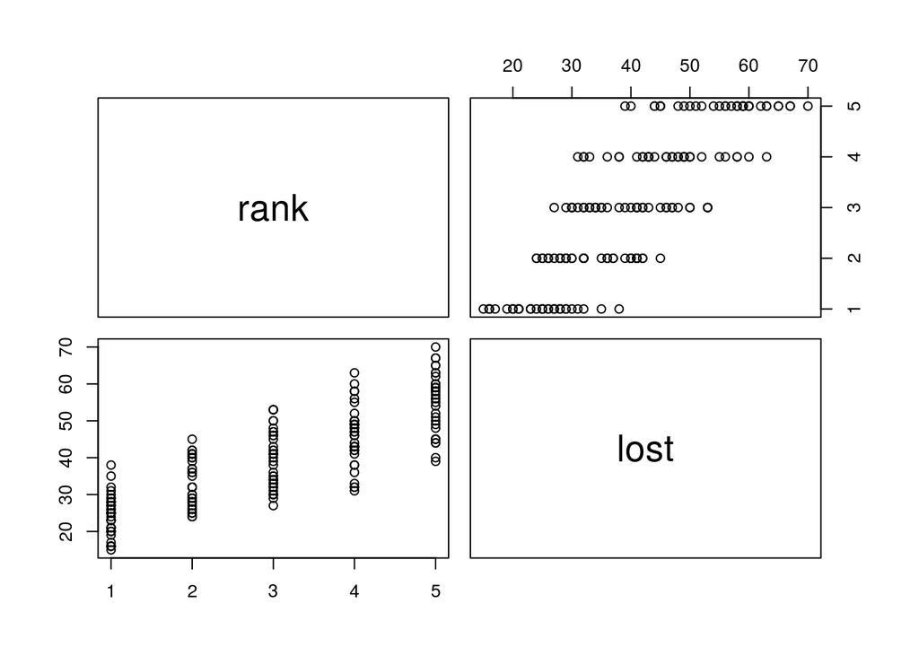

```r
rank3pm <- select(nba06To11, c("rank", "lost"))
pairs(rank3pm)
```

### Corrlation: calculation

Calculate correlation value [-1, 1]

```r
rankLostCorr <- cor(nba06To11$rank, nba06To11$lost)
rankLostCorr
```

```
## [1] 0.8307519
```

Rank and Games Lost correlation: 0.8307519.

### Univariate Linear Regression

Given 1 independent variable, predict the dependent variable. Given games lost, let’s predict the team’s rank.

### Get Training and Testing Sets

sample.split(df$AnyColumn, SplitRatio = decimal)

```r
# Set the random seed for repeatability
set.seed(123)

# Split the data into 3:1 ratio
sample = sample.split(nba06To11$rank, SplitRatio = .75)
train = subset(nba06To11, sample == TRUE)
test  = subset(nba06To11, sample == FALSE)
```

### Build Model on Training Set

```r
rankLostModel <- lm(rank ~ lost, data = train)
rankLostModel
```

```
##
## Call:
## lm(formula = rank ~ lost, data = train)
##
## Coefficients:
## (Intercept)         lost
##    -0.73888      0.09362
```

### Prediction

```r
# Predict the position with the model and test data
predictedRank <- predict(rankLostModel, test)
predictedRank
```

```
##      1221      1224      1228      1231      1243      1247      1248      1250
## 3.8485855 0.6654469 2.0697728 3.0059900 3.8485855 2.1633945 3.0996117 0.7590686
##      1262      1268      1274      1284      1290      1293      1296      1299
## 4.8784245 4.7848028 1.6952859 2.2570162 5.1592897 2.9123683 3.7549638 4.7848028
##      1303      1306      1307      1310      1321      1325      1326      1331
## 1.8825293 3.8485855 2.4442597 2.2570162 1.6016641 5.5337766 5.8146418 4.4103159
##      1337      1338      1345      1347      1359      1360      1362      1365
## 1.9761510 4.5039376 2.2570162 3.5677204 1.7889076 2.0697728 3.1932335 1.2271772
##      1367      1369      1370      1371      1373      1377      1378      1389
## 3.2868552 1.6952859 1.7889076 4.7848028 3.4740986 3.2868552 2.2570162 1.0399338
##      1390      1392      1393      1397      1398
## 1.9761510 2.3506379 2.8187466 2.0697728 3.5677204
```

```r
# Create data frame with actual and predicted values
rankPrediction <- data.frame(Lost = test$lost,
                             ActualRank = test$rank,
                             PredictedRank = predictedRank)

rankPrediction
```

```
##      Lost ActualRank PredictedRank
## 1221   49          4     3.8485855
## 1224   15          1     0.6654469
## 1228   30          3     2.0697728
## 1231   40          2     3.0059900
## 1243   49          5     3.8485855
## 1247   31          1     2.1633945
## 1248   41          2     3.0996117
## 1250   16          1     0.7590686
## 1262   60          5     4.8784245
## 1268   59          5     4.7848028
## 1274   26          2     1.6952859
## 1284   32          3     2.2570162
## 1290   63          4     5.1592897
## 1293   39          3     2.9123683
```

[output cut: 31 more lines]

Given a loss count of 28, predict the rank.

```r
# Create a data frame with a single 3pa entry
testSet <- data.frame(lost = c(28))
# Predict the position with the model and test data
predictedRank <- predict(rankLostModel, testSet)
predictedRank
```

```
##        1
## 1.882529
```

At 28 games lost, the rank should be approximately, 1.8825293.

### Verification

Let’s see the average rank at 28 loss count

```r
# Output table with loss of 28
lost28 <- subset(nba06To11, lost == 28)
lost28
```

```
##      year lgID tmID franchID confID divID rank confRank playoff
## 1277 2007  NBA  UTA      UTA     WC    NW    1        4      CS
## 1285 2008  NBA  DEN      DEN     WC    NW    1        2      CF
## 1303 2008  NBA  POR      POR     WC    NW    2        4      C1
## 1305 2008  NBA  SAS      SAS     WC    SW    1        3      C1
## 1332 2009  NBA  PHO      PHO     WC    PC    2        0      CF
## 1375 2011  NBA  DEN      DEN     WC    NW    2        0      C1
##                        name o_fgm o_fga o_ftm o_fta o_3pm o_3pa o_oreb o_dreb
## 1277              Utah Jazz  3279  6592  1745  2298   407  1095    942   2410
## 1285         Denver Nuggets  3058  6510  1891  2487   548  1477    905   2507
## 1303 Portland Trail Blazers  3018  6494  1521  1988   596  1555   1060   2360
## 1305      San Antonio Spurs  3042  6534  1249  1641   625  1620    728   2638
## 1332           Phoenix Suns  3339  6788  1631  2117   730  1770    910   2616
## 1375         Denver Nuggets  2572  5404  1293  1760   435  1311    738   2105
##      o_reb o_asts o_pf o_stl o_to o_blk o_pts d_fgm d_fga d_ftm d_fta d_3pm
```

[output cut: 34 more lines]

```r
# Calculate the average and sd of rank when 3pa is 1500
avgRank <- mean(lost28$rank)
avgRank
```

```
## [1] 1.5
```

```r
sdRank <- sd(lost28$rank)
sdRank
```

```
## [1] 0.5477226
```

At 28 losses the average rank is actually 1.5 with a standard deviation of 0.5477226.

### Games Lost vs. Rank

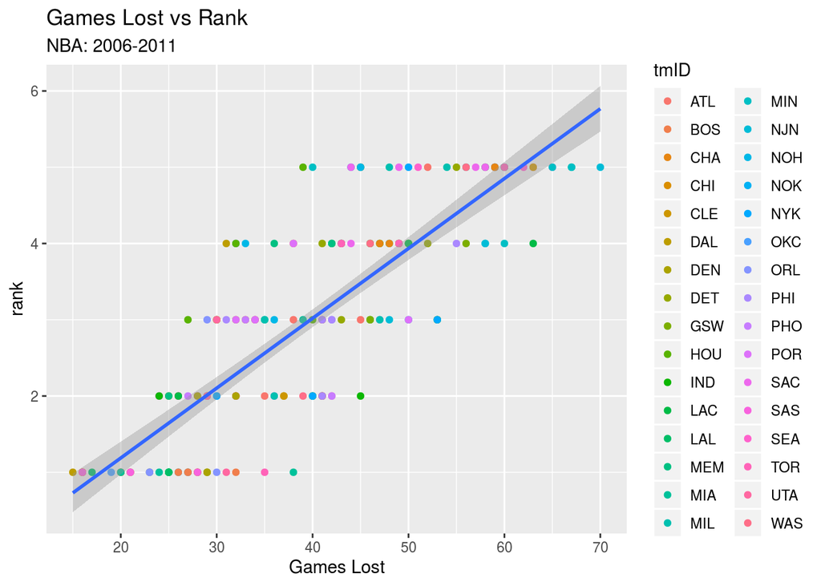

```r
ggplot(data = nba06To11, mapping = aes(x = lost, y = rank)) +
  geom_point(mapping = aes(color = tmID)) +
  geom_smooth(method = "lm") +
  labs(title = "Games Lost vs Rank" ,
         subtitle = "NBA: 2006-2011" ,
         x = "Games Lost")
```

### Visualize the prediction

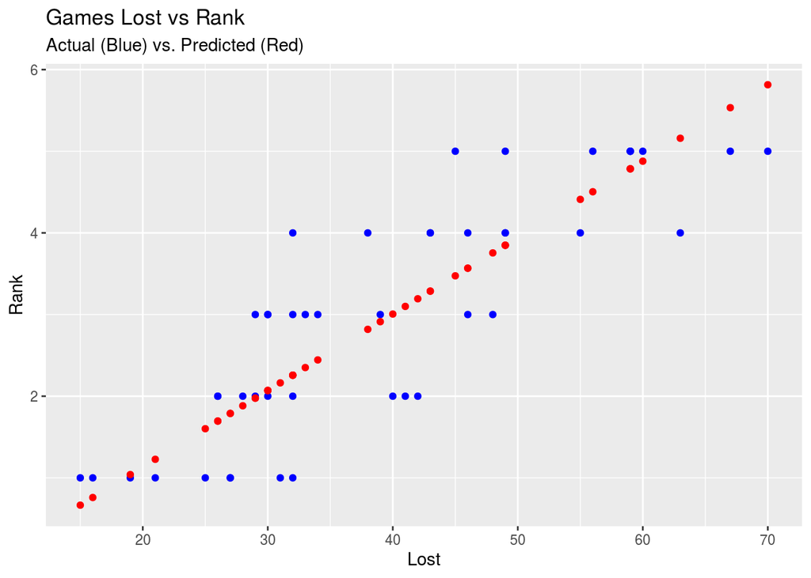

```r
ggplot(data = rankPrediction, mapping = aes(x = Lost)) +
  geom_point(data = rankPrediction,
             mapping = aes(y = ActualRank),
             color = "blue") +
  geom_point(data = rankPrediction,
             mapping = aes(y = PredictedRank),
             color = "red") +
  labs(title = "Games Lost vs Rank" ,
      subtitle = "Actual (Blue) vs. Predicted (Red)",
      y = "Rank")
```